# Sales_data_14_EDA

```python
#-- load csv file
import pandas as pd

df = pd.read_csv('Sales_2014.csv')
```

#### Task 1: Data Preparation

##### 1. Load and inspect dataset (first 5 rows, data types, missing values).

##### 2. Clean data: convert dates to datetime, handle missing values, create Total Sales.

```python
#first 5 rows
df.head(5)
```

|  | Order ID | Customer ID | SalesPerson | Order Date | Order Priority | SKU | Order Quantity | Unit Sell Price | Discount | Shipping Amount | Ship Mode | Product Container | Ship Date |
| --- | --- | --- | --- | --- | --- | --- | --- | --- | --- | --- | --- | --- | --- |
| 0 | 13729 | C508 | Bob | 1/1/2014 | Not Specified | SKU947 | 9 | 95.99 | 0.08 | 35.00 | Express Air | Large Box | 1/3/2014 |
| 1 | 28774 | C372 | John | 1/1/2014 | High | SKU937 | 32 | 5.98 | 0.10 | 4.69 | Regular Air | Small Box | 1/2/2014 |
| 2 | 9285 | C212 | Bob | 1/2/2014 | Critical | SKU363 | 3 | 40.98 | 0.06 | 2.99 | Regular Air | Small Box | 1/4/2014 |
| 3 | 37537 | C015 | Bob | 1/2/2014 | Low | SKU052 | 4 | 291.73 | 0.00 | 48.80 | Delivery Truck | Jumbo Drum | 1/2/2014 |
| 4 | 37537 | C015 | Bob | 1/2/2014 | Low | SKU063 | 43 | 100.98 | 0.07 | 45.00 | Delivery Truck | Jumbo Drum | 1/4/2014 |

```python
df.dtypes
```

```
Order ID               int64
Customer ID           object
SalesPerson           object
Order Date            object
Order Priority        object
SKU                   object
Order Quantity         int64
Unit Sell Price      float64
Discount             float64
Shipping Amount      float64
Ship Mode             object
Product Container     object
Ship Date             object
dtype: object
```

```python
# Convert Order Date and Ship Date to datetime format
df['Order Date'] = pd.to_datetime(df['Order Date'])
df['Ship Date'] = pd.to_datetime(df['Ship Date'])

df.dtypes
```

```
Order ID                      int64
Customer ID                  object
SalesPerson                  object
Order Date           datetime64[ns]
Order Priority               object
SKU                          object
Order Quantity                int64
Unit Sell Price             float64
Discount                    float64
Shipping Amount             float64
Ship Mode                    object
Product Container            object
Ship Date            datetime64[ns]
dtype: object
```

```python
df.isnull().sum().sort_values(ascending=False)
```

```
Order ID             0
Customer ID          0
SalesPerson          0
Order Date           0
Order Priority       0
SKU                  0
Order Quantity       0
Unit Sell Price      0
Discount             0
Shipping Amount      0
Ship Mode            0
Product Container    0
Ship Date            0
dtype: int64
```

```python
#-- Create Total_sales column
df['Total Sales'] = df['Order Quantity'] * df['Unit Sell Price'] * (1 - df['Discount'])
df[['Order Date', 'Ship Date', 'Total Sales']].head()
```

|  | Order Date | Ship Date | Total Sales |
| --- | --- | --- | --- |
| 0 | 2014-01-01 | 2014-01-03 | 794.7972 |
| 1 | 2014-01-01 | 2014-01-02 | 172.2240 |
| 2 | 2014-01-02 | 2014-01-04 | 115.5636 |
| 3 | 2014-01-02 | 2014-01-02 | 1166.9200 |
| 4 | 2014-01-02 | 2014-01-04 | 4038.1902 |

```python
df.info()
```

```
<class 'pandas.core.frame.DataFrame'>
RangeIndex: 2153 entries, 0 to 2152
Data columns (total 14 columns):
 #   Column             Non-Null Count  Dtype
---  ------             --------------  -----
 0   Order ID           2153 non-null   int64
 1   Customer ID        2153 non-null   object
 2   SalesPerson        2153 non-null   object
 3   Order Date         2153 non-null   datetime64[ns]
 4   Order Priority     2153 non-null   object
 5   SKU                2153 non-null   object
 6   Order Quantity     2153 non-null   int64
 7   Unit Sell Price    2153 non-null   float64
 8   Discount           2153 non-null   float64
 9   Shipping Amount    2153 non-null   float64
 10  Ship Mode          2153 non-null   object
 11  Product Container  2153 non-null   object
 12  Ship Date          2153 non-null   datetime64[ns]
 13  Total Sales        2153 non-null   float64
dtypes: datetime64[ns](2), float64(4), int64(2), object(6)
memory usage: 235.6+ KB
```

#### Task 2: Salesperson Performance

##### 1. Plot total sales by salesperson (bar plot).

##### 2. Recommend a bonus recipient, considering total sales and another factor (e.g., order count). Propose a new metric and justify in 2-3 sentences.

```python
#-- Group and Sum Total Sales by Salesperson in one dataframe

sales_by_person = df.groupby('SalesPerson')['Total Sales'].sum().sort_values(ascending=False)
sales_df = sales_by_person.reset_index()
sales_df['Total Sales'] = sales_df['Total Sales'].round(0).astype(int).apply(lambda x: f"{x:,}")
sales_df
```

|  | SalesPerson | Total Sales |
| --- | --- | --- |
| 0 | Richard | 1,542,980 |
| 1 | Bob | 1,373,385 |
| 2 | John | 1,232,242 |

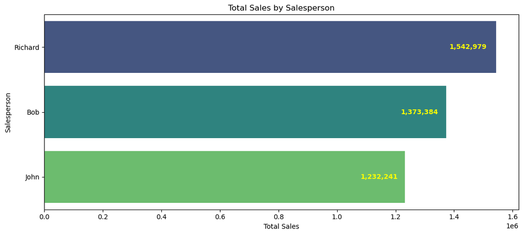

```python
#-- Bar Plot
import matplotlib.pyplot as plt
import seaborn as sns
import warnings
warnings.filterwarnings("ignore")

plt.figure(figsize=(11, 5))
ax = sns.barplot(x=sales_by_person.values, y=sales_by_person.index, palette='viridis')

for i, value in enumerate(sales_by_person.values):
    ax.text(value * 0.98, i, f'{int(value):,}', va='center', ha='right', color='yellow', fontsize=10, fontweight='bold')

plt.xlabel('Total Sales')
plt.ylabel('Salesperson')
plt.title('Total Sales by Salesperson')
plt.tight_layout()
plt.show()
```

```python
from numpy import log1p
#-- Total sales,order count by salesperson
sales_summary = df.groupby('SalesPerson').agg({'Total Sales': 'sum', 'Order ID': 'count'}).rename(columns={'Order ID': 'Order Count'})

#-- Sales Score = Total Sales * log(Order Count + 1)  -- new metric
sales_summary['Sales Score'] = sales_summary['Total Sales'] * log1p(sales_summary['Order Count'])

#-- change data_types & formate
sales_summary['Total Sales'] = sales_summary['Total Sales'].round(0).astype(int)
sales_summary['Sales Score'] = sales_summary['Sales Score'].round(0).astype(int)
sales_summary['Order Count'] = sales_summary['Order Count'].astype(int)

sales_summary = sales_summary.sort_values(by='Sales Score', ascending=False)

sales_summary
```

| SalesPerson | Total Sales | Order Count | Sales Score |
| --- | --- | --- | --- |
| Richard | 1542980 | 729 | 10172935 |
| Bob | 1373385 | 730 | 9056667 |
| John | 1232242 | 694 | 8063680 |

Bonus Recommendation:- Bonus should go to Richard.Richard generated the highest total sales and handled a very high number of orders as well.